# Inferential Statistics

Fall 2024

## Expanding on Hypothesis Testing

- 1-tailed
  - Hypothesis includes an **expected direction**.

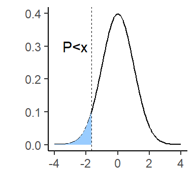

- Decrease
- Cooler
- Smaller
- Lower

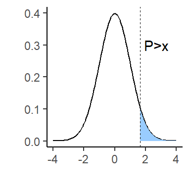

- Increase
- Warmer
- Higher
- Expand

## Expanding on Hypothesis Testing

- 1-tailed - hypothesis includes an **expected direction**.

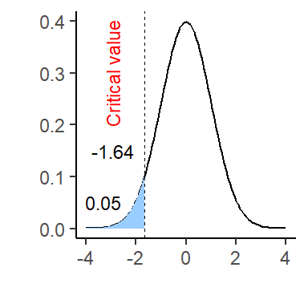

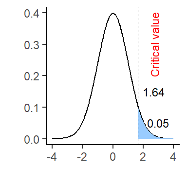

- If your obtained test statistic falls beyond the critical value (lightblue) for your given Alpha threshold = Significant result, **reject the null**.

## Expanding on Hypothesis Testing

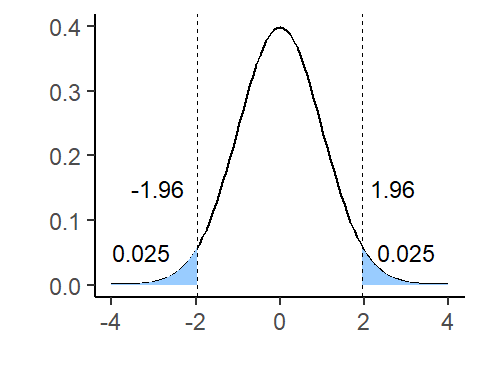

## Significant or Not?

- **Not significant**:
- Accept the null hypothesis.
- There is **no** difference between the sample and population mean.
- Obtained test statistic < critical value threshold.
- p-value > alpha threshold (usually 0.05).

**Significant**:

- Reject the null hypothesis,
- There **is** a difference between the sample and population mean.
- Obtained test statistic > critical value threshold.
- p-value < alpha threshold (usually 0.05).

## Basic steps for an **Inferential Test**

- A statement of null hypothesis:
- Choose the appropriate test:
- Set the level of Type I error risk (alpha):
- Analyze data distribution:

## Basic steps for an **Inferential Test**

\(y = \beta_0 + \beta_1 x + \epsilon\)

where:  
- \(y\) is the dependent variable,  
- \(x\) is the independent variable,  
- \(\beta_0\) is the intercept,  
- \(\beta_1\) is the slope,  
- \(\epsilon\) is the error term.

## Basic steps for an **Inferential Test**

- We can select an appropriate test simply by answering some questions.
  - How many variables, how many groups are we including? (multivariate)
  - Are observations independent from each other or purposely paired?
  - Is my data not normally distributed? (non-parametric tests)

## Statistical shorthand **z-test** example

\(z_{(100)} = 1.4, p = 0.16\)

## Statistical shorthand **z-test** example

\(z_{(100)} = 1.4, \, p = 0.16\) \[ \text{\huge $\downarrow$} \quad \] \[ \underbrace{z_{\underbrace{(100)}_{\text{Sample size}}}}_{\text{Test statistic}} = \underbrace{1.4}_{\text{z-value}}, \quad \underbrace{p = 0.16}_{\text{p-value}} \]

- Every statistical test has a letter designating the type of test.
- Because power is so closely tied to sample size, we report sample size.
- For clarity (and to confirm the correct-tailed test is used to assess the p-value), include the calculated test statistic value.
- Always report the p-value.
- Some tests will also include a secondary metric to assess how meaningful results are (if significant).

## How to summarize your analysis: Key Components of a Statistical Summary

## How to summarize your analysis: Key Components of a Statistical Summary

## When would you run a one-sample z-test?

- Use the One Sample z-test when:
  - You want to test for a **difference** between one **sample mean** and a larger **population mean**.
  - There is only **one group (sample)** being tested against the larger **population**.
  - You know (or can estimate) the mean and standard deviation of the population.
  - Data is normally distributed.

\[ z = \frac{\bar{X} - \mu}{\frac{\sigma}{\sqrt{n}}} \]

where:  
- \(\bar{X}\): Sample mean.  
- \(\mu\): Population mean.  
- \(\sigma\): Population standard deviation. - \(n\): Sample size.

## When would you run a one-sample z-test?

- Use the One Sample z-test when:
  - You want to test for a **difference** between one **sample mean** and a larger **population mean**.
  - There is only **one group (sample)** being tested against the larger **population**.
  - You know (or can estimate) the mean and standard deviation of the population.
  - Data is normally distributed.

## Flowcharts:

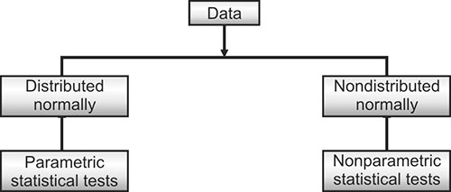

## Flowcharts

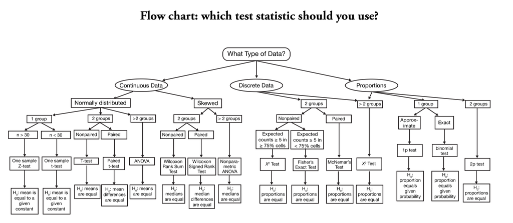

## Flowcharts

[interactive chart not shown]

## One sample z-test

Assume you have a sample of **20 observations**. The mean of this **sample is 150**, and you want to determine whether there is a **difference between the sample mean and the larger population mean**. Since you are not specifying a direction for this difference, you will conduct a two-tailed test.

The **population mean is 164**, and the **population standard deviation is 33**.

Next, calculate the obtained value for this **one-sample z-test.**

\[ z = \frac{\bar{X} - \mu}{\frac{\sigma}{\sqrt{n}}} \]

\[ z = \frac{150 - 164}{\frac{33}{\sqrt{20}}} = -1.897 \]

## One sample z-test

Assume you have a sample of **20 observations**. The mean of this **sample is 150**, and you want to determine whether there is a **difference between the sample mean and the larger population mean**. Since you are not specifying a direction for this difference, you will conduct a two-tailed test.

The **population mean is 164**, and the **population standard deviation is 33**.

Next, calculate the obtained value for this **one-sample z-test.**

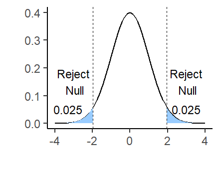

\[ z = \frac{150 - 164}{\frac{33}{\sqrt{20}}} = -1.897 \]

## Critical Value Approach

- In the critical value approach, we compare the calculated **test statistic** to the **critical value** from the standard normal distribution. For a **two-tailed test** at the \(\alpha = 0.05\) significance level, the critical values are approximately ±1.96, which corresponds to the **0.025** in each tail.
- Decision Rule
- If \(| \text{calculated test statistic} | > \text{critical value}\) = **Significant**
- If \(| \text{calculated test statistic} | \leq \text{critical value}\) = **Not Significant**

## Critical Value Approach

In this case:

\[ |-1.897| < 1.96 \]

- Thus, we fail to reject the null hypothesis, indicating that there is **no significant** difference between the sample mean and the population mean.

## Finding the p-value

Now we need to determine the probability (p-value) associated with the calculated test statistic. You have several options to achieve this:

```r
z_value <- -1.897
p_value <- 2 * pnorm(z_value)  # Two-tailed p-value
p_value  # This will give the result
```

```
## [1] 0.05782794
```

- Since this p-value (0.0578) is greater than the alpha threshold of 0.05, we conclude that the result is **not significant**.

## Example: Car rental

## Example: Car rental

- A rental car company claims the mean time to rent a car on their **website is 60 seconds with a standard deviation of 30 seconds**. A random sample **36 customers** attempted to rent a car on the website. The **mean time to rent was 75 seconds**. Is this enough evidence to contradict the company’s claim?
- Step 1: Set up the hypotheses
- **Null hypothesis (\(H_0\))**: The mean rental time is 60 seconds. \[ H_0: \mu = 60 \]
- **Alternative hypothesis (\(H_1\))**: The mean rental time is greater than 60 seconds. \[ H_1: \mu > 60 \]

## Example: Car rental

- A rental car company claims the mean time to rent a car on their **website is 60 seconds with a standard deviation of 30 seconds**. A random sample **36 customers** attempted to rent a car on the website. The **mean time to rent was 75 seconds**. Is this enough evidence to contradict the company’s claim?
- Step 2: Test statistic formula

\[ z = \frac{\bar{X} - \mu}{\frac{\sigma}{\sqrt{n}}} \]

\[ z = \frac{75 - 60}{\frac{30}{\sqrt{36}}} = \frac{15}{5} = 3 \]

## Example: Car rental

- A rental car company claims the mean time to rent a car on their **website is 60 seconds with a standard deviation of 30 seconds**. A random sample **36 customers** attempted to rent a car on the website. The **mean time to rent was 75 seconds**. Is this enough evidence to contradict the company’s claim?
- Step 2: Test statistic formula

\[ |3| > 1.645 \]

\[ z = \frac{75 - 60}{\frac{30}{\sqrt{36}}} = \frac{15}{5} = 3 \]

## Example: Car rental

For a **one-tailed test** at a significance level of **\(\alpha = 0.05\)**, the critical z-value is approximately **1.645** (since we are only looking at one tail).

```r
# Given z-value
z_value <- 3
# Calculate the one-tailed p-value
p_value <- 1 - pnorm(z_value)
# Print the p-value
p_value
```

```
## [1] 0.001349898
```

## Example: Car rental

## Example: Another example

## Example: Another example

A water quality regulation specifies that the lead level in drinking water should be no more than **15 ppb** ( \(\mu\)) with a standard deviation \(\sigma\) = 0.25. A random sample of three lead measurements yielded values of 15.84, 15.33, and 15.58. Perform a one-sided z-test to determine if the mean lead level exceeds 15 ppb.

\[ H_0: \mu = 15 \]

\[ H_1: \mu > 15 \]

## Example: Another example

library(BSDA)

z.test(x, alternative=‘greater’, mu=, sigma.x=)

where:

- x: values for the first sample
- alternative: the alternative hypothesis (‘greater’, ‘less’, ‘two.sided’)
- mu: mean population.
- sigma.x: population standard deviation,

## Example: Another example

```
##
##  One-sample z-Test
##
## data:  water_sample
## z = 4.0415, p-value = 2.656e-05
## alternative hypothesis: true mean is greater than 15
## 95 percent confidence interval:
##  15.34592       NA
## sample estimates:
## mean of x
##  15.58333
```

The test statistic for the one-sample **z-test is 4.0415** and the corresponding **p-value is \(p = 2.66 \times 10^{-5}\)**.

## Example: Another example